# Preliminary Analysis

Nicolas Restrepo

11/15/2019

## Data Preparation

```r
# Packages
library(tidyverse)
library(knitr)
library(kableExtra)
library(ggrepel)
library(gridExtra)
library(haven)
library(lavaan)
library(lme4)
library(nlme)
library(stargazer)
library(broom)
library(psych)
library(brms)
theme_set(theme_light())
```

I will begin by importing the data and getting it ready for analysis. Given that that the surveys were fielded at different points, there is a fair amount of merging we need to do.

```r
# Load in the conservative data
c_data <- read_csv("data/conservatives_full.csv")

#Get rid of the first 2 rows

c_data <- c_data[-(1:2), ]

# Load pretest data

p_data <- read_csv("data/pretest.csv")

p_data <- p_data[-(1:3), ]

# Load the liberal data

l_data <- read_csv("data/liberals_complete.csv")

l_data <- l_data[-(1:2),]

# Now bind them together

data <- rbind(c_data, p_data, l_data)
```

Having merged the data I will filter the respondents who failed the attention checks. I will also create a variable to distinguish between liberals and conservatives.

```r
# Get attention checks for the data

data <- data %>%
  mutate(passed_1 = ifelse(ach_1_1 == "extremely harmful", 1, 0),
         passed_2 = ifelse(ach_2_1 == "not at all immoral", 1, 0),
         passed_3 = ifelse(ach_3_1 == "moderately unexpected", 1, 0),
         passed_4 = ifelse(ach_4_1 == "not at all harmful", 1, 0),
         passed_5 = ifelse(ach_5_1 == "extremely immoral", 1, 0),
         passed_6 = ifelse(ach_6_1 == "extremely unexpected", 1, 0),
         sum_pass = passed_1 + passed_2 + passed_3 + passed_4 + passed_5 + passed_6)

# Now drop cases which did not pass the attention checks

data <- data %>%
  filter(sum_pass == 6)

# Create variable that indicates if someone is conservative

data <- data %>%
  mutate(conservative = ifelse(ideology_1 == 5 | ideology_1 == 6 | ideology_1 == 7, 1, 0))

data %>%
  group_by(conservative) %>%
  summarise(n())
```

```
## # A tibble: 2 x 2
##   conservative `n()`
##          <dbl> <int>
## 1            0    99
## 2            1    95
```

In total, we have 194 usable cases (99 liberals and 95 conservatives).

I am also going to recode the data so we get numbers instead of strings.

```r
# Mutate all main questions so that we get numbers

data <- data %>%
  mutate_at(vars(contains("_h_1")), funs(recode(.,
                                   "not at all harmful" = 1,
                                   "slightly harmful" = 2,
                                   "moderately harmful" = 3,
                                   "very harmful" = 4,
                                   "extremely harmful" = 5))) %>%
  mutate_at(vars(contains("_i_1")), funs(recode(.,
                                   "not at all immoral" = 1,
                                   "slightly immoral" = 2,
                                   "moderately immoral" = 3,
                                   "very immoral" = 4,
                                   "extremely immoral" = 5))) %>%
  mutate_at(vars(contains("_u_1")), funs(recode(.,
                                   "not at all unexpected" = 1,
                                   "slightly unexpected" = 2,
                                   "moderately unexpected" = 3,
                                   "very unexpected" = 4,
                                   "extremely unexpected" = 5)))
```

For now, I am going to select only the ratings for each event and the respondent’s political ideology:

```r
# Get of of the first set of uninformative columns

d <- data %>%
  select(-contains("ach")) %>%
  select(pkp_h_1:msas_u_1, ideology_1, conservative)

# Now let's create a more amenable dataset

d <- d %>%
  mutate(id = 1:n()) %>%
  select(id, everything())

# Rename all variables

d <- d %>%
  rename_all(
    funs(str_remove(., "_1"))
    ) %>%
  mutate_if(is.character, as.numeric)
```

Now we have a manageable wide dataframe. However, at this point, it would also be useful to put the data into a long format. This will help us conduct multilevel analysis and make certain visualizations.

```r
# Reshape harmful perceptions from wide to long

d_harm_long <- d %>%
  select(id, ideology, conservative, contains("_h")) %>%
  gather(key = "scenario", value = "harm", 4:28) %>%
  mutate(scenario = str_remove(scenario, "_h$"))

# Reshape immoral perceptions from wide to long

d_imm_long <- d %>%
  select(id, ideology, conservative, contains("_i")) %>%
  gather(key = "scenario", value = "immoral", 4:28) %>%
  mutate(scenario = str_remove(scenario, "_i$"))

# Reshape unexpected perceptions from wide to long

d_un_long <- d %>%
select(id, ideology, conservative, contains("_u")) %>%
  gather(key = "scenario", value = "unexpected", 4:28) %>%
  mutate(scenario = str_remove(scenario, "_u$"))

# Now join them

d_long <- d_harm_long %>%
  mutate(immoral = d_imm_long$immoral,
         unexpected = d_un_long$unexpected)
```

Now I am going to create a column for each moral foundation and I will also add the information for each event.

```r
# Load dataset with the deflections

selected_events <- read_csv("data/full_events.csv")

# Create column for abreviations

events <- c("pch",
            "pkp",
            "tmdp",
            "adr",
            "elb",
            "acr",
            "jbd",
            "scc",
            "ddf",
            "git",
            "idb",
            "ayc",
            "sip",
            "ecc",
            "ccr",
            "mbr",
            "msn",
            "mbw",
            "php",
            "mmc",
            "mmls",
            "msas",
            "mpsa",
            "whh",
            "thls")

# Create new column

events_def <- selected_events %>%
  mutate(scenario = events) %>%
  select(scenario, def, type, 5:33)

# Add to long dataset

d_long <- d_long %>%
  left_join(events_def, by = "scenario")

# Create a variable for negative behavior

d_long <- d_long %>%
  mutate(neg_beh = ifelse(be < 0, 1, 0))
```

Alright, now we are done with the data preparation. We can move on to some descriptive analysis.

## Descriptive Analysis

I am going to make some descriptive plots for the average scores for each question on all three dimensions. To do this I first need to create a summary table.

```r
# create a summary table for the values of each question

gd <- d %>%
  select(-c(id, ideology, conservative)) %>%
  gather(key = "scenario",
         value = "score") %>%
  group_by(scenario) %>%
  summarise_all(funs(med = median(.), avg = mean(.), maximum = max(.), minimum = min(.), st_dv = sd(.), fq = quantile(., 0.25), tq = quantile(., 0.75)))

gd <- gd %>%
  mutate(scenario = str_replace(scenario, "acr", "athlete_cheats_rival"),
         scenario = str_replace(scenario, "adr", "athlete_deceives_referee"),
         scenario = str_replace(scenario, "ayc", "athlete_yells_at_coach"),
         scenario = str_replace(scenario, "ccr", "coach_cheers_rival"),
         scenario = str_replace(scenario, "ddf", "daughter_disobeys_father"),
         scenario = str_replace(scenario, "ecc", "employee_conspires_with_comp."),
         scenario = str_replace(scenario, "elb", "employee_lies_to_boss"),
         scenario = str_replace(scenario, "git", "girl_interrupts_teacher"),
         scenario = str_replace(scenario, "idb", "intern_disobeys_boss"),
         scenario = str_replace(scenario, "jbd", "judge_befriends_defendant"),
         scenario = str_replace(scenario, "mbr", "man_betrays_relative"),
         scenario = str_replace(scenario, "mbw", "man_betrays_wife"),
         scenario = str_replace(scenario, "mmc", "man_marries_cousin"),
         scenario = str_replace(scenario, "mmls", "man_makes_love_sister"),
         scenario = str_replace(scenario, "mpsa", "married_has_sex_adulterer"),
         scenario = str_replace(scenario, "msas", "mother_sexually_arouses_son"),
         scenario = str_replace(scenario, "msn", "mayor_slanders_neighbor"),
         scenario = str_replace(scenario, "pch", "person_hurts_child"),
         scenario = str_replace(scenario, "php", "person_hires_prostitute"),
         scenario = str_replace(scenario, "pkp", "person_kills_person"),
         scenario = str_replace(scenario, "scc", "student_cheats_classmate"),
         scenario = str_replace(scenario, "sip", "student_insults_professor"),
         scenario = str_replace(scenario, "thls", "teacher_hits_lazy_student"),
         scenario = str_replace(scenario, "whh", "wife_hits_husband"),
         scenario = str_replace(scenario, "tmdp", "teenager_mocks_disabled"))
```

Now that we have the table, we can produce the plots.

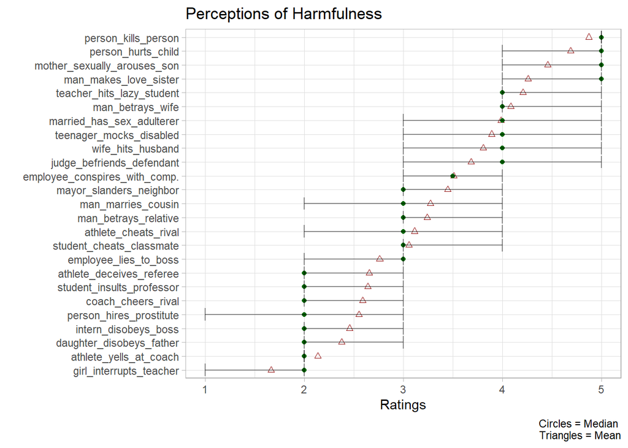

```r
# Keep only harm questions

gdh <- gd[str_which(gd$scenario, "_h$"),]

# Plot harm questions

gdh %>%
  mutate(scenario = str_remove(scenario, "_h$")) %>%
  ggplot(aes(x = reorder(scenario, avg), y = avg)) +
  geom_point(col = "darkred", fill = "darkred", pch = 2) +
  geom_point(aes(y = med), col = "darkgreen", fill = "darkgreen") +
  geom_errorbar(aes(ymin = fq, ymax = tq), alpha = .45) +
  coord_flip() +
  labs(x = "",
       y = "Ratings",
       title = "Perceptions of Harmfulness",
       caption = "Circles = Median \nTriangles = Mean")
```

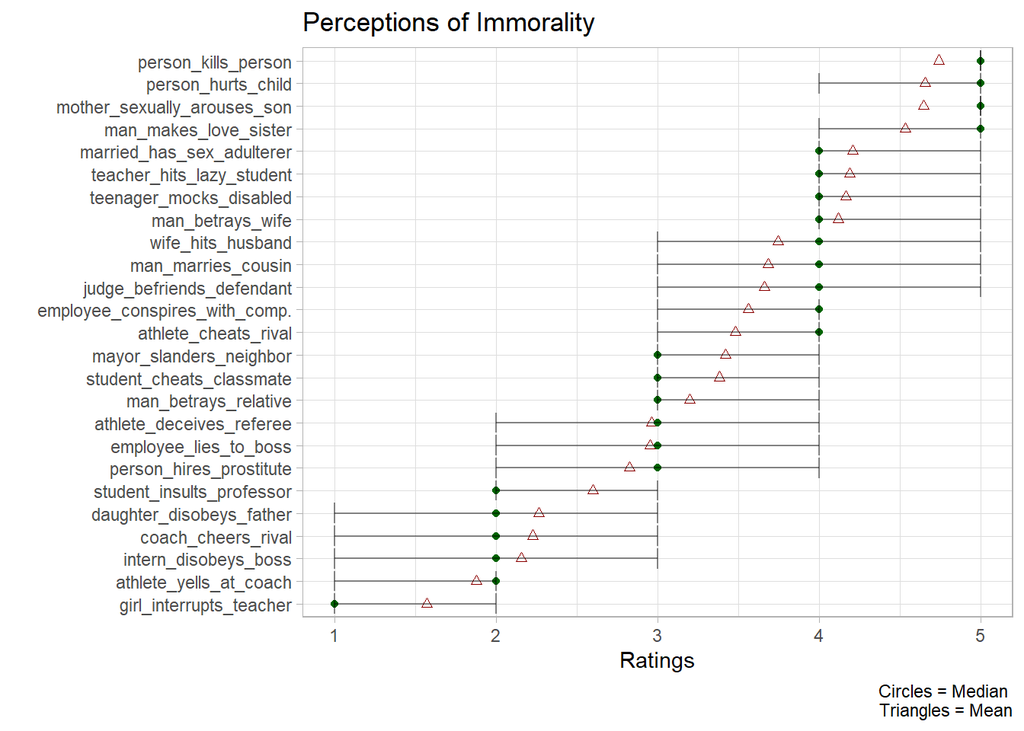

```r
# Now lets look at immorality

gdi <- gd[str_which(gd$scenario, "_i$"),]

# Plot immorality

gdi %>%
  mutate(scenario = str_remove(scenario, "_i$")) %>%
  ggplot(aes(x = reorder(scenario, avg), y = avg)) +
  geom_point(col = "darkred", fill = "darkred", pch = 2) +
  geom_point(aes(y = med), col = "darkgreen", fill = "darkgreen") +
  geom_errorbar(aes(ymin = fq, ymax = tq), alpha = .45) +
  coord_flip() +
  labs(x = "",
       y = "Ratings",
       title = "Perceptions of Immorality",
       caption = "Circles = Median \nTriangles = Mean")
```

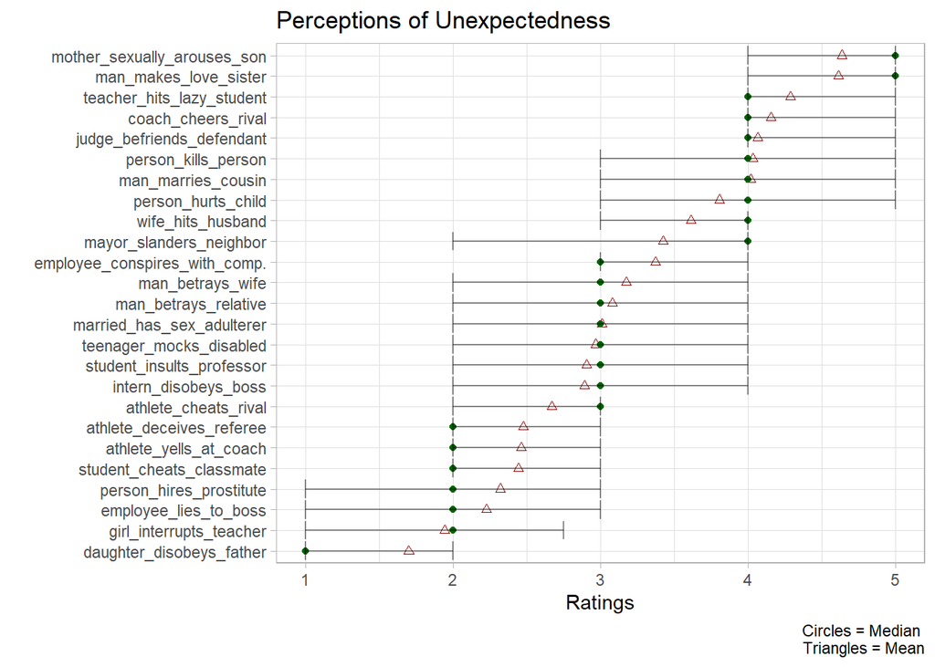

```r
# Lastly let's look at unexpectedness

gdu <- gd[str_which(gd$scenario, "_u$"),]

# Plot Unexpectedness

gdu %>%
  mutate(scenario = str_remove(scenario, "_u$")) %>%
  ggplot(aes(x = reorder(scenario, avg), y = avg)) +
  geom_point(col = "darkred", fill = "darkred", pch = 2) +
  geom_point(aes(y = med), col = "darkgreen", fill = "darkgreen") +
  geom_errorbar(aes(ymin = fq, ymax = tq), alpha = .45) +
  coord_flip() +
  labs(x = "",
       y = "Ratings",
       title = "Perceptions of Unexpectedness",
       caption = "Circles = Median \nTriangles = Mean")
```

We can look at whether the harmfulness ratings for purity trangressions differ between conservatives and liberals.

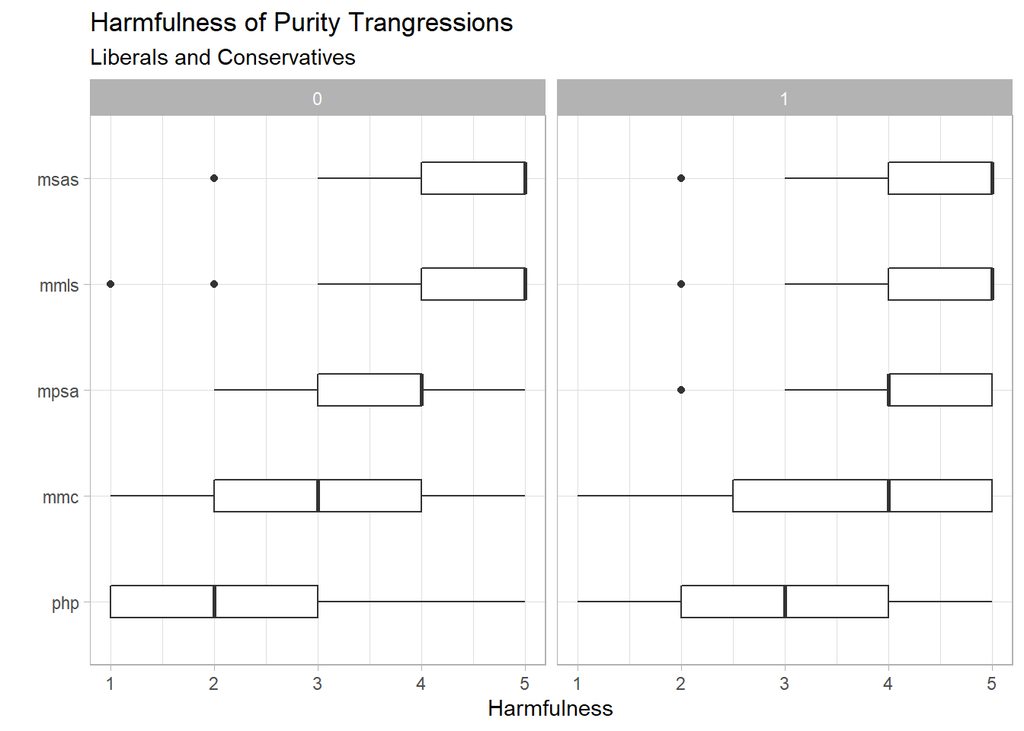

```r
d_long %>%
  filter(type == "purity") %>%
  ggplot(aes(x = reorder(scenario, harm), y = harm)) +
  geom_boxplot(width = 0.3, fill = "white") +
  coord_flip() +
  facet_wrap(~ conservative) +
  labs(x = "",
       y = "Harmfulness",
       title = "Harmfulness of Purity Trangressions",
       subtitle = "Liberals and Conservatives")
```

Here, conservatives are on the right and liberals on the left. Even though they seem to agree on the ranking of the harmfulness of purity trangressions, liberals seem overall more permissive. This is particularly true for adultery and prostitution.

The data also allow us to recreate the plot from Gray and Keeney (2015), where they visualize the average severity of events and their “weirdness”. In the next plot, then, I will put immorality in the x-axis and unexpectedness in the y-axis.

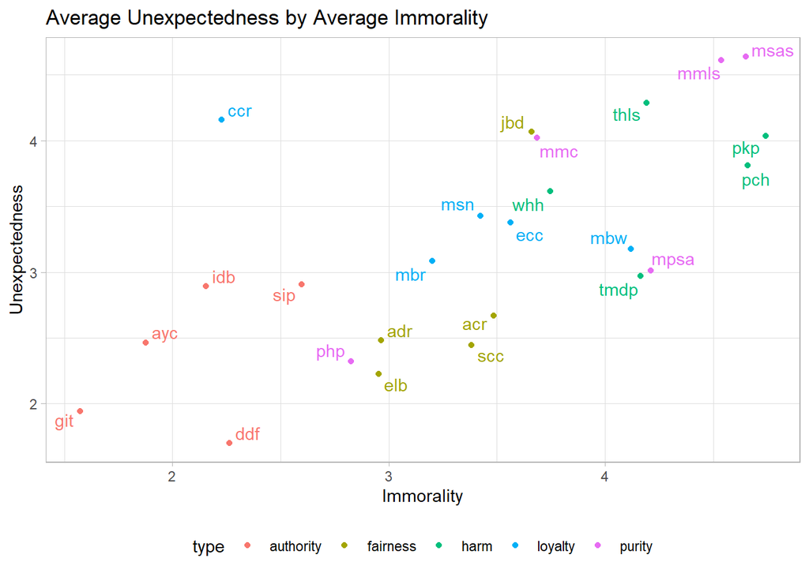

```r
# create mean measures from the long dataset

dsl <- d_long %>%
  group_by(scenario, type, def, dop) %>%
  summarise(mean_harm = mean(harm),
            mean_imm = mean(immoral),
            mean_unex = mean(unexpected))


# Recreate Gray and Keeney's plot

dsl %>%
  ggplot(aes(x = mean_imm, y = mean_unex, col = type)) +
  geom_point() +
  geom_text_repel(aes(label = scenario), show.legend = F) +
  theme(legend.position = "bottom") +
  guides(text = F) +
  labs(x = "Immorality",
       y = "Unexpectedness",
       title = "Average Unexpectedness by Average Immorality")
```

Some insights from Gray and Keeney (2015) still hold in our data. Certain purity trangressions are the most unexpected, but harmful wrongs are still the most severe. However, the plot suggests that the relationship between unexpectedness and severity is perhaps more linear than these authors have been willing to concede. They do argue that “weirdness” is related to morality insofar as it denotes norm violation. However, given the limited amount of scenarios they analyze, they do not have enough data to make this case convincingly. This relationship, nonetheless, is evident in our data.

Let’s look at the relationship between harm and unexpectedness, and harm and immorality.

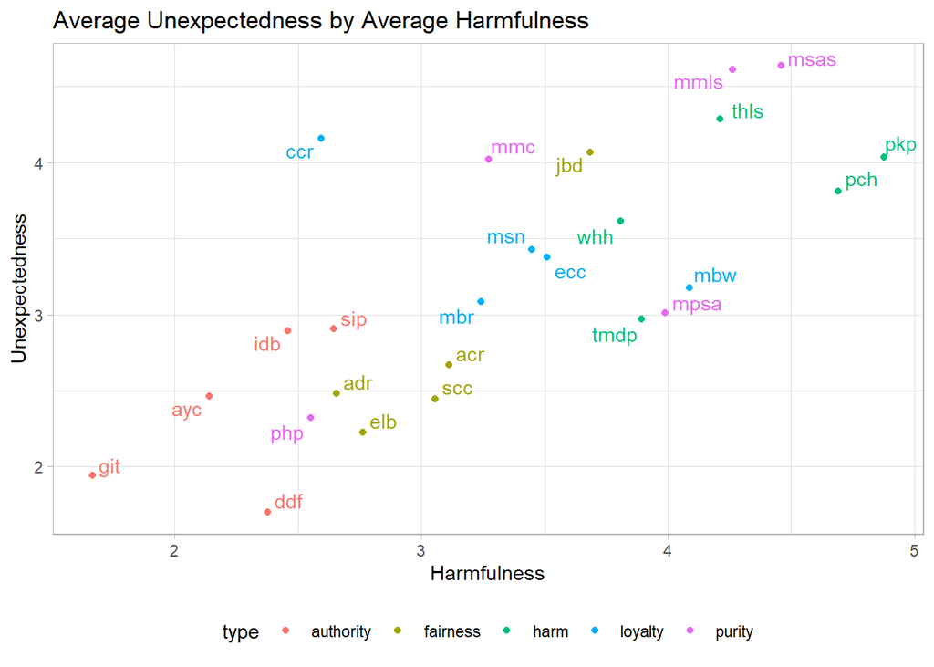

```r
# Plot harm by unexpectedness

dsl %>%
  ggplot(aes(x = mean_harm, y = mean_unex, col = type)) +
  geom_point() +
  geom_text_repel(aes(label = scenario), show.legend = F) +
  theme(legend.position = "bottom") +
  guides(text = F) +
  labs(x = "Harmfulness",
       y = "Unexpectedness",
       title = "Average Unexpectedness by Average Harmfulness")
```

The relationship here is similar to the one above. Unsurprisingly, the most unexpected scenarios are those involving purity and the most harmful are those involving harm. However, affirming Kurt’s ideas, there seems to be a relatively strong relationship between harmfulness and unexpectedness.

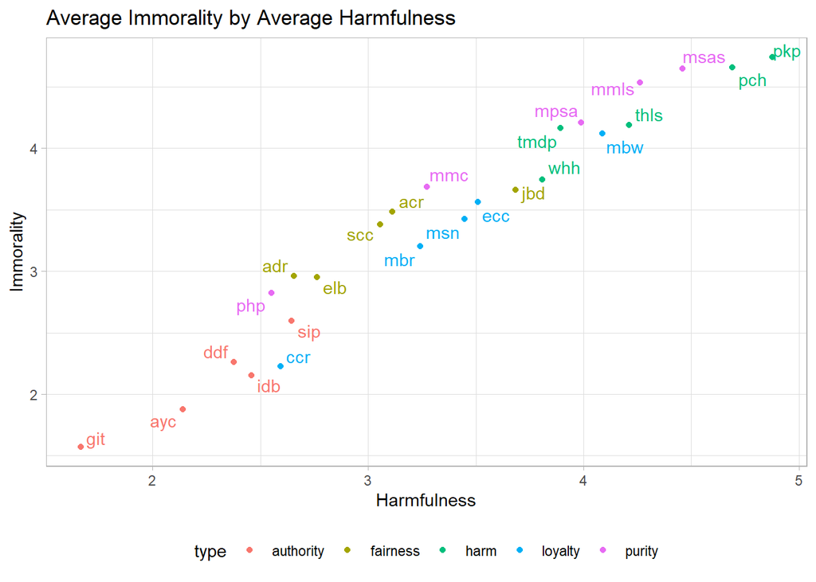

```r
# Plot harmfulness by immorality

dsl %>%
  ggplot(aes(x = mean_harm, y = mean_imm, col = type)) +
  geom_point() +
  geom_text_repel(aes(label = scenario), show.legend = F) +
  theme(legend.position = "bottom") +
  guides(text = F) +
  labs(y = "Immorality",
       x = "Harmfulness",
       title = "Average Immorality by Average Harmfulness")
```

Consistent with our previous analysis, this relatioship is very strong, almost forming a 45 degree line. Perceptions of harmfulness are highly informative of respondents’ conceptions of immorality.

To close this visualization section, I am going to look at how deflection relates to our three measures.

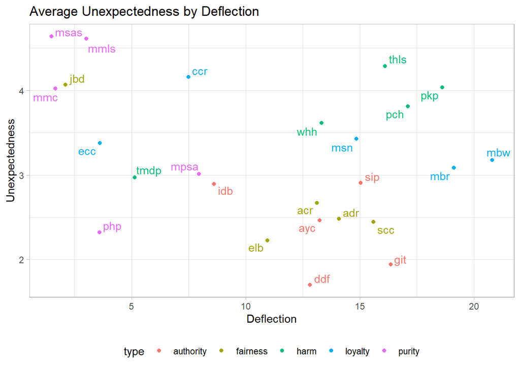

```r
# Unexpectedness by deflection

dsl %>%
  ggplot(aes(x = def, y = mean_unex, col = type)) +
  geom_point() +
  geom_text_repel(aes(label = scenario), show.legend = F) +
  theme(legend.position = "bottom") +
  guides(text = F) +
  labs(x = "Deflection",
       y = "Unexpectedness",
       title = "Average Unexpectedness by Deflection")
```

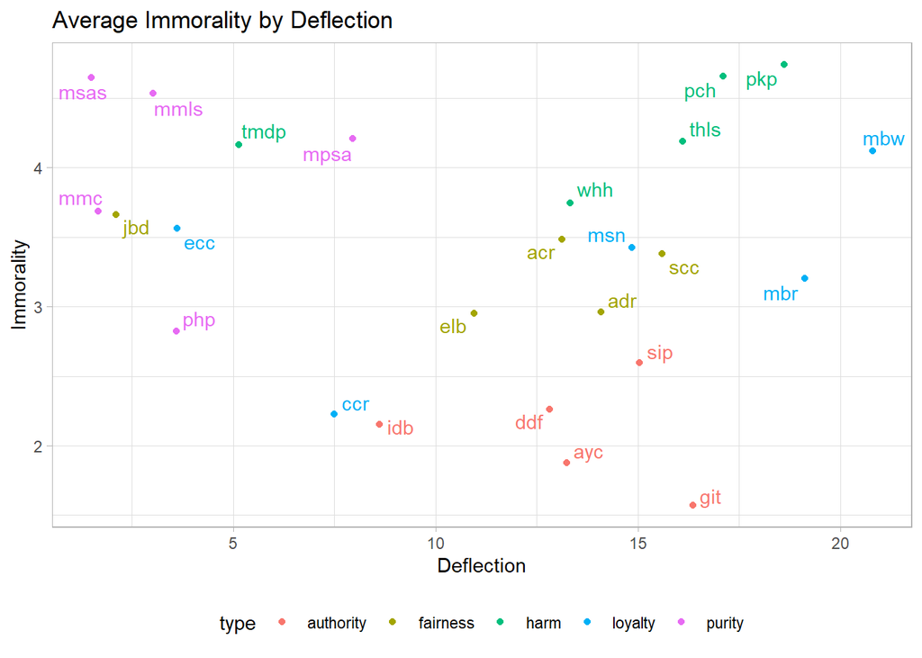

```r
# Immorality by deflection

dsl %>%
  ggplot(aes(x = def, y = mean_imm, col = type)) +
  geom_point() +
  geom_text_repel(aes(label = scenario), show.legend = F) +
  theme(legend.position = "bottom") +
  guides(text = F) +
  labs(x = "Deflection",
       y = "Immorality",
       title = "Average Immorality by Deflection")
```

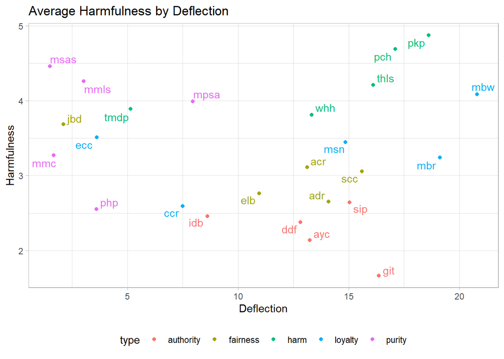

```r
# Harmfulness by deflection

dsl %>%
  ggplot(aes(x = def, y = mean_harm, col = type)) +
  geom_point() +
  geom_text_repel(aes(label = scenario), show.legend = F) +
  theme(legend.position = "bottom") +
  guides(text = F) +
  labs(x = "Deflection",
       y = "Harmfulness",
       title = "Average Harmfulness by Deflection")
```

To an extent, our data show the results that are similar to what we expected. Deflection seems adequate to predict the values of events that obviously involve harm, but it really misses the mark when it comes trangressions that invole breaches of “purity”. However, overall, deflection seems to have no relationship with either immorality or unexpectedness. The latter relationship is particularly troubling because “unexpectedness” maps on closely to the idea that the concept of deflection is meant to capture.

## First Analysis

I am going to try to fit multi-level models to see what best predicts immorality. For these initial exploratory models, I will be using nlme. I will let the intercepts for participants and scenarios vary, but here I won’t explore more co-variances.

I am going to scale all the variables first.

```r
# Scale all variables before the analysis
d_long_scaled <-
  d_long %>%
  mutate_at(c("id", "type", "scenario", "conservative", "neg_beh"), ~as.factor(.)) %>%
  mutate_if(is.numeric, scale)
```

Now, I am going to predict immorality on our main questions. In the most complex model, I will include an interaction effect between conservatism and the type of moral foundation. This accounts for the idea that political ideology mediates how much weight is placed on the different moral foundations.

```r
# Fit initial model
m1 <- lme(fixed = immoral ~ harm + def + unexpected,
           data = d_long_scaled,
           random =  ~  1  | scenario/id)

summary(m1)
```

```
## Linear mixed-effects model fit by REML
##  Data: d_long_scaled
##        AIC      BIC    logLik
##   7542.724 7588.126 -3764.362
##
## Random effects:
##  Formula: ~1 | scenario
##         (Intercept)
## StdDev:   0.2424592
##
##  Formula: ~1 | id %in% scenario
##         (Intercept)  Residual
## StdDev:   0.4852151 0.1862329
##
## Fixed effects: immoral ~ harm + def + unexpected
##                  Value  Std.Error   DF  t-value p-value
## (Intercept)  0.0000000 0.04906275 4823  0.00000  1.0000
## harm         0.6474695 0.01103439 4823 58.67740  0.0000
## def         -0.0296072 0.04910915   23 -0.60288  0.5525
## unexpected   0.1355027 0.01065837 4823 12.71327  0.0000
##  Correlation:
##            (Intr) harm   def
## harm        0.000
## def         0.000 -0.015
## unexpected  0.000 -0.458  0.041
##
## Standardized Within-Group Residuals:
##          Min           Q1          Med           Q3          Max
## -2.008007729 -0.173002331 -0.006534808  0.177605437  1.744887950
##
## Number of Observations: 4850
## Number of Groups:
##         scenario id %in% scenario
##               25             4850
```

```r
# Fit model controlling for conservatism
m2 <- lme(fixed = immoral ~ harm + def + unexpected + conservative,
           data = d_long_scaled,
           random =  ~  1 | scenario/id)

summary(m2)
```

```
## Linear mixed-effects model fit by REML
##  Data: d_long_scaled
##       AIC      BIC    logLik
##   7546.03 7597.916 -3765.015
##
## Random effects:
##  Formula: ~1 | scenario
##         (Intercept)
## StdDev:   0.2435367
##
##  Formula: ~1 | id %in% scenario
##         (Intercept)  Residual
## StdDev:   0.4849839 0.1861662
##
## Fixed effects: immoral ~ harm + def + unexpected + conservative
##                    Value  Std.Error   DF  t-value p-value
## (Intercept)   -0.0168674 0.04982156 4822 -0.33856  0.7350
## harm           0.6453442 0.01106722 4822 58.31131  0.0000
## def           -0.0298332 0.04932152   23 -0.60487  0.5512
## unexpected     0.1345916 0.01066145 4822 12.62414  0.0000
## conservative1  0.0344451 0.01502592 4822  2.29238  0.0219
##  Correlation:
##               (Intr) harm   def    unxpct
## harm           0.012
## def            0.000 -0.015
## unexpected     0.006 -0.453  0.041
## conservative1 -0.148 -0.082 -0.002 -0.038
##
## Standardized Within-Group Residuals:
##          Min           Q1          Med           Q3          Max
## -2.020632475 -0.173280093 -0.002102483  0.175740094  1.731278414
##
## Number of Observations: 4850
## Number of Groups:
##         scenario id %in% scenario
##               25             4850
```

```r
# Add moral foundations to the model and add an interaction with conservatism
m3 <- lme(fixed = immoral ~ harm + def + unexpected + conservative*type,
           data = d_long_scaled,
           random =  ~  1 | scenario/id)

summary(m3)
```

```
## Linear mixed-effects model fit by REML
##  Data: d_long_scaled
##        AIC     BIC    logLik
##   7519.935 7623.68 -3743.967
##
## Random effects:
##  Formula: ~1 | scenario
##         (Intercept)
## StdDev:   0.1524887
##
##  Formula: ~1 | id %in% scenario
##         (Intercept)  Residual
## StdDev:   0.4835337 0.1834299
##
## Fixed effects: immoral ~ harm + def + unexpected + conservative * type
##                                 Value  Std.Error   DF  t-value p-value
## (Intercept)                -0.3896599 0.07423982 4818 -5.24866  0.0000
## harm                        0.6387653 0.01108422 4818 57.62834  0.0000
## def                         0.0635636 0.04136583   19  1.53662  0.1409
## unexpected                  0.1332331 0.01057801 4818 12.59529  0.0000
## conservative1               0.0794882 0.03324935 4818  2.39067  0.0169
## typefairness                0.5442639 0.10307115   19  5.28047  0.0000
## typeharm                    0.5096641 0.10350261   19  4.92417  0.0001
## typeloyalty                 0.2405794 0.10230851   19  2.35151  0.0296
## typepurity                  0.5662854 0.12255948   19  4.62049  0.0002
## conservative1:typefairness -0.1741999 0.04697582 4818 -3.70829  0.0002
## conservative1:typeharm     -0.1242042 0.04704778 4818 -2.63996  0.0083
## conservative1:typeloyalty  -0.0409234 0.04698894 4818 -0.87092  0.3838
## conservative1:typepurity    0.1205841 0.04704131 4818  2.56337  0.0104
##  Correlation:
##                            (Intr) harm   def    unxpct cnsrv1 typfrn typhrm
## harm                        0.102
## def                        -0.204 -0.038
## unexpected                  0.024 -0.451  0.055
## conservative1              -0.225 -0.033  0.000 -0.011
## typefairness               -0.714 -0.059  0.138  0.007  0.160
## typeharm                   -0.685 -0.135 -0.055 -0.026  0.164  0.489
## typeloyalty                -0.695 -0.053  0.002 -0.041  0.163  0.497  0.504
## typepurity                 -0.694 -0.076  0.548 -0.011  0.137  0.492  0.393
## conservative1:typefairness  0.155 -0.002  0.000  0.001 -0.706 -0.223 -0.111
```

[output cut: 23 more lines]

```
## typeloyalty
## typepurity
## conservative1:typefairness
## conservative1:typeharm
## conservative1:typeloyalty
## conservative1:typepurity    0.500
##
## Standardized Within-Group Residuals:
##          Min           Q1          Med           Q3          Max
## -1.984414866 -0.171722178  0.006458982  0.176652870  1.651385249
##
## Number of Observations: 4850
## Number of Groups:
##         scenario id %in% scenario
##               25             4850
```

Here, the best fitting model is actually the most parsimonious one. Harm significantly predicts immorality and so does unexpectedness. Deflection, however, is a poor predictor of wrongdoing. One thing to take into account here is that there is not a lot of variation in deflection - we only have 25 data points - and, therefore, establishing relationships can be difficult. However, the sign and the magnitudes of the coefficients do not speak favorably of deflection’s capacity to predict immorality.

The third model is worth mentioning. Although the difference between conservatives and liberals is significant, it is not necessarily considerable. Interestingly, though, the interaction effects are also significant. The effect of “purity” on immorality, for instance, is bigger amongst conservatives than it is amongst liberals. Given the small overall differences, nonetheless, it is important not to overemphasize these mediating effects. However, it is a finding worth noting.

Perhaps a more direct test of deflection’s explanatory power in the moral domain would be to test its capacity to account for unexpectedness.

```r
# Unexpectedness exaplained by harm, immorality, and deflection

m4 <- lme( fixed = unexpected ~ 1 + def + harm + immoral,
           data = d_long_scaled,
           random =  ~  1 | scenario/id)

summary(m4)
```

```
## Linear mixed-effects model fit by REML
##  Data: d_long_scaled
##        AIC      BIC    logLik
##   10271.57 10316.97 -5128.784
##
## Random effects:
##  Formula: ~1 | scenario
##         (Intercept)
## StdDev:   0.4252228
##
##  Formula: ~1 | id %in% scenario
##         (Intercept)  Residual
## StdDev:   0.6407978 0.2501008
##
## Fixed effects: unexpected ~ 1 + def + harm + immoral
##                  Value  Std.Error   DF   t-value p-value
## (Intercept)  0.0000000 0.08561622 4823  0.000000  1.0000
## def         -0.1748639 0.08563172   23 -2.042046  0.0528
## harm         0.3031588 0.01860989 4823 16.290201  0.0000
## immoral      0.2387321 0.01872035 4823 12.752541  0.0000
##  Correlation:
##         (Intr) def    harm
## def      0.000
## harm     0.000 -0.006
## immoral  0.000  0.012 -0.714
##
## Standardized Within-Group Residuals:
##         Min          Q1         Med          Q3         Max
## -1.52470685 -0.22980773  0.02232252  0.24930171  1.18633218
##
## Number of Observations: 4850
## Number of Groups:
##         scenario id %in% scenario
##               25             4850
```

This model suggests that, in our data, deflection is not very informative for predicting unexpectedness, unlike harm and immorality. The coefficient for deflection, here, is on the verge of significance but its sign is the opposite of what one would expect. The model suggests that as deflection goes up, unexpectedness goes down. Undoubtedly, this result is being influenced by the low deflection / high unexpectedness events such as incest.

We can have a deeper look at whether the EPA profiles themselves tell us something about the immorality of acts. Similarly, we can examine whether transformations in these values - the individual components of deflection - are more informative than the aggregate value. I don’t think we should put all these predictors in the same model due to multicollinearity - EPA profiles and subsequent tranformations carry much of the same information. I will then fit two models: one for the EPA profiles of actors, behaviors, and objects; the second, for the difference between those values and the transient impressions.

```r
# Immorality predicted by the individual EPA profiles

m5 <- lme(fixed = immoral ~ 1 + ae + ap + aa + be + bp + ba + oe + op + oa,
           data = d_long_scaled,
           random =  ~  1 | scenario/id)

summary(m5)
```

```
## Linear mixed-effects model fit by REML
##  Data: d_long_scaled
##        AIC      BIC    logLik
##   11150.42 11234.72 -5562.212
##
## Random effects:
##  Formula: ~1 | scenario
##         (Intercept)
## StdDev:    0.576814
##
##  Formula: ~1 | id %in% scenario
##         (Intercept) Residual
## StdDev:   0.6999694 0.273958
##
## Fixed effects: immoral ~ 1 + ae + ap + aa + be + bp + ba + oe + op + oa
##                  Value Std.Error   DF    t-value p-value
## (Intercept)  0.0000000 0.1158666 4825  0.0000000  1.0000
## ae          -0.0023764 0.1709629   15 -0.0138999  0.9891
## ap           0.0147991 0.1865428   15  0.0793335  0.9378
## aa           0.0180529 0.1725456   15  0.1046270  0.9181
## be          -0.3674823 0.2134266   15 -1.7218208  0.1057
## bp           0.4921074 0.2483416   15  1.9815747  0.0662
## ba          -0.1910848 0.1420736   15 -1.3449707  0.1986
## oe           0.1286452 0.1572443   15  0.8181230  0.4261
## op          -0.3144356 0.1798385   15 -1.7484328  0.1008
## oa          -0.1339937 0.1599666   15 -0.8376359  0.4154
##  Correlation:
##    (Intr) ae     ap     aa     be     bp     ba     oe     op
## ae  0.000
## ap  0.000 -0.586
## aa  0.000  0.227 -0.566
## be  0.000 -0.039  0.156 -0.124
## bp  0.000  0.105 -0.393  0.426 -0.766
## ba  0.000 -0.318  0.174 -0.382 -0.032 -0.153
## oe  0.000  0.281 -0.361  0.397  0.024  0.251 -0.167
## op  0.000 -0.531  0.383 -0.201 -0.057  0.078  0.120 -0.457
## oa  0.000  0.160  0.040 -0.385  0.001 -0.269  0.328 -0.183 -0.365
##
## Standardized Within-Group Residuals:
##         Min          Q1         Med          Q3         Max
## -1.33565639 -0.23410642  0.04261485  0.26099193  1.21995361
##
## Number of Observations: 4850
## Number of Groups:
##         scenario id %in% scenario
##               25             4850
```

```r
# Immorality predicted by the transformations in EPA profiles

m6 <- lme(fixed = immoral ~ 1  + dae + dap + daa + dbe + dbp + dba + doe + dop + doa,
           data = d_long_scaled,
           random =  ~  1 | scenario/id)

summary(m6)
```

```
## Linear mixed-effects model fit by REML
##  Data: d_long_scaled
##        AIC      BIC    logLik
##   11148.44 11232.74 -5561.218
##
## Random effects:
##  Formula: ~1 | scenario
##         (Intercept)
## StdDev:   0.6385421
##
##  Formula: ~1 | id %in% scenario
##         (Intercept)  Residual
## StdDev:   0.6993315 0.2755823
##
## Fixed effects: immoral ~ 1 + dae + dap + daa + dbe + dbp + dba + doe + dop +      doa
##                  Value Std.Error   DF    t-value p-value
## (Intercept)  0.0000000 0.1281637 4825  0.0000000  1.0000
## dae         -0.0881660 0.2788029   15 -0.3162304  0.7562
## dap         -0.2534877 0.2336282   15 -1.0850047  0.2951
## daa          0.0579466 0.3058922   15  0.1894346  0.8523
## dbe          0.9205960 0.5444696   15  1.6908125  0.1115
## dbp         -0.9721607 0.6979308   15 -1.3929185  0.1839
## dba          0.0793238 0.2890215   15  0.2744564  0.7875
## doe         -0.5001255 0.3233652   15 -1.5466272  0.1428
## dop          0.6552827 0.2758789   15  2.3752550  0.0313
## doa          0.0593015 0.1933025   15  0.3067810  0.7632
##  Correlation:
##     (Intr) dae    dap    daa    dbe    dbp    dba    doe    dop
## dae  0.000
## dap  0.000  0.160
## daa  0.000  0.182  0.024
## dbe  0.000 -0.027 -0.644 -0.464
## dbp  0.000  0.348  0.747  0.453 -0.879
## dba  0.000 -0.268 -0.055  0.727 -0.461  0.246
## doe  0.000  0.031  0.484  0.381 -0.620  0.675  0.258
## dop  0.000 -0.019 -0.079 -0.076  0.336 -0.172 -0.175 -0.541
## doa  0.000 -0.217 -0.068 -0.311 -0.003 -0.193  0.125 -0.073 -0.450
##
## Standardized Within-Group Residuals:
##         Min          Q1         Med          Q3         Max
## -1.34115451 -0.23557194  0.04307042  0.26306662  1.22719200
##
## Number of Observations: 4850
## Number of Groups:
##         scenario id %in% scenario
##               25             4850
```

Both models seem to fit the data poorly (their BICs are quite high). Again, they suggests that these data do not allow us to make any solid inferences about the relationship between the EPA profiles associated with the elements of moral statements and their perceived immorality. The only value that comes close to the threshold of significance is the potency of the behavior. As behaviors become more potent, immorality appears to increase. However, we cannot draw strong conclusions from this.

The second model is similar in its poor fit and in the high p-values of its coefficients. One coefficient, nonetheless, reaches significance: the change in potency of the object. It might appear counterintuitive but it’s an artifact of the scale. All chosen events except for one - a person hires a prostitute - lower the potency of the object. However, the events that seem to lower the potency of the object the least are amongst the most immoral - such as a person hurting a child or a teacher hitting a lazy student. In this dataset, then, the events that lower the potency of the object the least are associated with more perceived immorality. Given that the scales are centered, this is what the coefficient is telling us.

I will close this preliminary analysis by examining the predictive capacity of the EPA profiles - and the differences - when we exclude the purity trangressions. The rationale here is that ACT does a poor job predicting the deflection of these type of moral wrongdoings. If we exclude them, then, we could see whether this theory can pick up some generalities about the other set of trangressions.

```r
# Run model with EPA scores on a sample excluding the purity scenarios
m8 <- lme( fixed = immoral ~ 1 + ae + ap + aa + be + bp + ba + oe + op + oa,
           data = filter(d_long_scaled, type != "purity"),
           random =  ~  1 | scenario/id)

summary(m8)
```

```
## Linear mixed-effects model fit by REML
##  Data: filter(d_long_scaled, type != "purity")
##        AIC      BIC    logLik
##   8751.705 8833.098 -4362.852
##
## Random effects:
##  Formula: ~1 | scenario
##         (Intercept)
## StdDev:   0.3279818
##
##  Formula: ~1 | id %in% scenario
##         (Intercept)  Residual
## StdDev:   0.6876925 0.2624927
##
## Fixed effects: immoral ~ 1 + ae + ap + aa + be + bp + ba + oe + op + oa
##                  Value  Std.Error   DF   t-value p-value
## (Intercept) -0.1187635 0.08657747 3860 -1.371760  0.1702
## ae          -0.2024450 0.13704285   10 -1.477238  0.1704
## ap           0.0747727 0.11826928   10  0.632224  0.5414
## aa          -0.0603175 0.12057924   10 -0.500231  0.6277
## be          -0.5027616 0.14133959   10 -3.557118  0.0052
## bp           0.2970758 0.15463807   10  1.921104  0.0837
## ba          -0.1393586 0.10575682   10 -1.317727  0.2170
## oe          -0.1391586 0.16178017   10 -0.860171  0.4098
## op          -0.3164100 0.12761993   10 -2.479315  0.0326
## oa          -0.0418991 0.09898314   10 -0.423295  0.6810
##  Correlation:
##    (Intr) ae     ap     aa     be     bp     ba     oe     op
## ae  0.139
## ap -0.113 -0.654
## aa  0.086  0.428 -0.637
## be  0.305  0.145 -0.010  0.055
## bp  0.149  0.231 -0.453  0.507 -0.468
## ba -0.188 -0.553  0.384 -0.577 -0.243 -0.300
## oe  0.167  0.554 -0.498  0.651  0.244  0.417 -0.556
## op -0.205 -0.653  0.517 -0.391 -0.251 -0.087  0.429 -0.572
## oa -0.008  0.021  0.105 -0.459 -0.049 -0.335  0.363 -0.343 -0.223
##
## Standardized Within-Group Residuals:
##         Min          Q1         Med          Q3         Max
## -1.33566868 -0.23352456  0.01238583  0.26456957  1.21798233
##
## Number of Observations: 3880
## Number of Groups:
##         scenario id %in% scenario
##               20             3880
```

```r
m9 <- lme( fixed = immoral ~ 1 + dae + dap + daa + dbe + dbp + dba + doe + dop + doa,
           data = filter(d_long_scaled, type != "purity"),
           random =  ~  1 | scenario/id)

summary(m9)
```

```
## Linear mixed-effects model fit by REML
##  Data: filter(d_long_scaled, type != "purity")
##        AIC      BIC    logLik
##   8753.949 8835.343 -4363.975
##
## Random effects:
##  Formula: ~1 | scenario
##         (Intercept)
## StdDev:   0.4749998
##
##  Formula: ~1 | id %in% scenario
##         (Intercept) Residual
## StdDev:   0.6866322 0.265254
##
## Fixed effects: immoral ~ 1 + dae + dap + daa + dbe + dbp + dba + doe + dop +      doa
##                  Value Std.Error   DF   t-value p-value
## (Intercept) -0.0550732 0.1276426 3860 -0.431464  0.6662
## dae         -0.2445025 0.3449572   10 -0.708791  0.4946
## dap         -0.2736263 0.1930127   10 -1.417660  0.1867
## daa         -0.1574950 0.2611600   10 -0.603059  0.5599
## dbe          1.2614405 0.5167739   10  2.440991  0.0348
## dbp         -1.4031745 0.5915139   10 -2.372175  0.0391
## dba          0.1124067 0.2544361   10  0.441788  0.6680
## doe         -0.8512979 0.4194013   10 -2.029793  0.0698
## dop          0.9220246 0.2838617   10  3.248148  0.0087
## doa          0.1162632 0.1467364   10  0.792327  0.4466
##  Correlation:
##     (Intr) dae    dap    daa    dbe    dbp    dba    doe    dop
## dae  0.280
## dap -0.220 -0.164
## daa -0.028 -0.205  0.113
## dbe  0.224  0.432 -0.678 -0.576
## dbp -0.233 -0.088  0.776  0.496 -0.877
## dba -0.074 -0.527  0.065  0.766 -0.575  0.319
## doe -0.261 -0.591  0.527  0.549 -0.782  0.680  0.499
## dop  0.293  0.455 -0.302 -0.315  0.610 -0.427 -0.372 -0.768
## doa -0.083 -0.186 -0.022 -0.273 -0.037 -0.134  0.128 -0.008 -0.361
##
## Standardized Within-Group Residuals:
##         Min          Q1         Med          Q3         Max
## -1.34701651 -0.23727205  0.01167717  0.26272746  1.23146586
##
## Number of Observations: 3880
## Number of Groups:
##         scenario id %in% scenario
##               20             3880
```

The first thing to notice is that the BICs for these models is dramatically lower. We cannot compare them directly with the models fit above because the number of observations is not the same. However, it is worth bearing in mind that the EPA values seem to be a lot more informative when the purity scenarios are excluded.

The first model shows interesting results. The coefficients for the behavior’s evaluation and the object’s potency are both significant. This resonates with Kurt’s theory. As the evaluation of the behaviors go up, the immorality of a scenario sinificantly decreases. This is - reassuringly - what we would expect: behaviors that have low-evaluation are perceived as more immoral. The coefficient for the object’s potency, in turn, suggests that as this value increases, the immorality of the act tends to decrease. I think this is an important finding because it speaks directly to Kurt’s idea of vulnerability. As actors appear less potent, the behaviors directed at them are considered more immoral. This adds plausibility to the notion that the vulnerability of the victim is key when assessing immorality.

## Conclusion

Let me recap some of the most important points here.

1. We can show results similar to those presented by Gray and Keeney but we can also extend them. We have more data to show that unexpectedness is tied to immorality and that “purity” transgressions are still considered quite harmful.
2. Deflection and EPA components are not predictive of immorality. However, when we exclude the purity scenarios from the analysis, we notice that EPAs are informative in predictable yet interesting ways. I think this works well with what we have been thinking. Deflections and EPA fail when it comes to purity scenarios because these events have “weird” structures: they involve good behaviors, which usually don’t lower the potency of objects very much. If this line of argument is defensible - and methodologically sound - we have made good progress in explaining what’s “weird” about harmless wrongs.